# Zotero group AMA

Published

16 October 2026

Zotero data of 16 October 2026 · IPBES Literature Report 0.4.0 · [source code on GitHub](https://github.com/IPBES-Data/IPBES.LiteratureReport)

This report shows the state of the Zotero group **AMA** ([open the group in Zotero](https://www.zotero.org/groups/2333011)). It gives an overview of the literature in the group, and lists the items which should be corrected.

Each item in the lists can be opened in the Zotero **web** library or in the Zotero **app** on your computer, so that it can be corrected directly. Corrected items disappear from the lists the next time the report is updated. Some checks compare the items with [OpenAlex](https://openalex.org), an open catalogue of scholarly publications.

## Summary

| Status | Check | Items |
| --- | --- | --- |
| ● OK | Retracted publications | 0 |
| ● Please fix | DOI points to a different publication | 187 |
| ● Please fix | Items which are in the group more than once | 9 |
| ● Please fix | DOI field with an invalid DOI | 8 |
| ● Please fix | DOI field with a link or prefix instead of the DOI | 4 |
| ● Please check | ISSN not in the standard form | 1548 |
| ● Please check | DOI in the wrong field | 17 |
| ● Please check | DOI not found in OpenAlex | 22 |
| ● Please check | Missing or unusual publication year | 9 |
| ● Please check | Empty journal, volume, issue or pages, found in OpenAlex | 53 |
| ● Please check | Language not given as a language code | 34 |
| ● Please check | Items without DOI, ISBN, ISSN or URL | 552 |
| ● Please check | Items without DOI, for which OpenAlex has one | 235 |
| ● OK | OpenAlex ID in Extra not valid | 0 |
| ● For information | Items without their OpenAlex ID in Extra | 2310 |
| ● OK | Items without tags | 0 |

**Please fix**: these items contain errors. **Please check**: these items may need a correction. **For information**: no action needed unless the group uses this, e.g. tags.

## Items to fix

The lists are sorted by importance. Use the search field above a list to find an item. **web** opens the item in the Zotero web library, **app** in the Zotero app.

### Retracted publications

These publications have been retracted. Check whether they should still be cited, and mark or remove them in Zotero.

**✔ Nothing to fix.**

### DOI points to a different publication

The DOI of these items leads to a publication with a different title or year. Usually the DOI is wrong: open the DOI to see where it leads, and correct it in Zotero. Differences of one year (e.g. published online before print) are not listed.

| Open in Zotero | Title in Zotero | Year in Zotero | The DOI leads to | Its year | DOI |
| --- | --- | --- | --- | --- | --- |
| <a href="https://www.zotero.org/groups/2333011/items/QRCL6QQW" target="_blank">web</a> &middot; <a href="zotero://select/groups/2333011/items/QRCL6QQW">app</a> | Check-List of North American Birds | 2010 | Check-List of North American Birds | 1958 | <a href="https://doi.org/10.2307/4510687" target="_blank">10.2307/4510687</a> |
| <a href="https://www.zotero.org/groups/2333011/items/F369E3AS" target="_blank">web</a> &middot; <a href="zotero://select/groups/2333011/items/F369E3AS">app</a> | The US fire learning network: Springing a rigidity trap through multiscalar collaborative networks | 2010 | The Weakest Link | 2008 | <a href="https://doi.org/10.1177/0002764207312000" target="_blank">10.1177/0002764207312000</a> |
| <a href="https://www.zotero.org/groups/2333011/items/NYKWFA3Y" target="_blank">web</a> &middot; <a href="zotero://select/groups/2333011/items/NYKWFA3Y">app</a> | Ecological Implications of Changes in Drought Patterns: Shifts in Forest Composition in Panama | 2013 | Ecological Implications of Changes in Drought Patterns: Shifts in Forest Composition in Panama | 1998 | <a href="https://doi.org/10.1007/978-94-017-2730-3_12" target="_blank">10.1007/978-94-017-2730-3_12</a> |
| <a href="https://www.zotero.org/groups/2333011/items/P7QWIUG7" target="_blank">web</a> &middot; <a href="zotero://select/groups/2333011/items/P7QWIUG7">app</a> | Biological invasion of the Indo-Pacific lionfish Pterois volitans along the Atlantic coast of North America Biological invasion of the Indo-Pacific lionfish Pterois volitans along the Atlantic coast o… | 2015 | Biological invasion of the Indo-Pacific lionfish Pterois volitans along the Atlantic coast of North America | 2002 | <a href="https://doi.org/10.3354/meps235289" target="_blank">10.3354/meps235289</a> |
| <a href="https://www.zotero.org/groups/2333011/items/MFSJYZAI" target="_blank">web</a> &middot; <a href="zotero://select/groups/2333011/items/MFSJYZAI">app</a> | How Grazing and Soil Quality Affect Native and Exotic Plant Diversity in Rocky Mountain Grasslands Published by : Ecological Society of America HOW GRAZING AND SOIL QUALITY AFFECT NATIVE AND EXOTIC | 2010 | HOW GRAZING AND SOIL QUALITY AFFECT NATIVE AND EXOTIC PLANT DIVERSITY IN ROCKY MOUNTAIN GRASSLANDS | 1999 | <a href="https://doi.org/10.1890/1051-0761(1999)009[0045:hgasqa]2.0.co;2" target="_blank">10.1890/1051-0761(1999)009[0045:hgasqa]2.0.co;2</a> |
| <a href="https://www.zotero.org/groups/2333011/items/BRPYIMIS" target="_blank">web</a> &middot; <a href="zotero://select/groups/2333011/items/BRPYIMIS">app</a> | Heavy Metals Structure Benthic Communities in Colorado Mountain Streams HEAVY METALS STRUCTURE BENTHIC COMMUNITIES IN COLORADO MOUNTAIN STREAMS | 2011 | HEAVY METALS STRUCTURE BENTHIC COMMUNITIES IN COLORADO MOUNTAIN STREAMS | 2000 | <a href="https://doi.org/10.1890/1051-0761(2000)010[0626:hmsbci]2.0.co;2" target="_blank">10.1890/1051-0761(2000)010[0626:hmsbci]2.0.co;2</a> |
| <a href="https://www.zotero.org/groups/2333011/items/DQKLUVJ6" target="_blank">web</a> &middot; <a href="zotero://select/groups/2333011/items/DQKLUVJ6">app</a> | Convergence or Divergence: What Should We Expect from Vegetation Succession? | 2006 | Convergence or Divergence: What Should We Expect from Vegetation Succession? | 1991 | <a href="https://doi.org/10.2307/3545274" target="_blank">10.2307/3545274</a> |
| <a href="https://www.zotero.org/groups/2333011/items/M4SJG9B8" target="_blank">web</a> &middot; <a href="zotero://select/groups/2333011/items/M4SJG9B8">app</a> | Biotic Invasions: Causes, Epidemiology, Global Consequences, and Control | 2000 | ISSUES IN ECOLOGY | 2005 | <a href="https://doi.org/10.1890/0012-9623(2005)86[249b:iie]2.0.co;2" target="_blank">10.1890/0012-9623(2005)86[249b:iie]2.0.co;2</a> |
| <a href="https://www.zotero.org/groups/2333011/items/G3JFMZH4" target="_blank">web</a> &middot; <a href="zotero://select/groups/2333011/items/G3JFMZH4">app</a> | The Influence of Climate and Soils on the Distribution of Four African Grasses | 2007 | The Influence of Climate and Soils on the Distribution of Four African Grasses | 1988 | <a href="https://doi.org/10.2307/3898948" target="_blank">10.2307/3898948</a> |
| <a href="https://www.zotero.org/groups/2333011/items/4KPP5867" target="_blank">web</a> &middot; <a href="zotero://select/groups/2333011/items/4KPP5867">app</a> | Reconstructing the lionfish invasion: insights into Greater Caribbean biogeography: Reconstructing the lionfish invasion | 2011 | Reconstructing the lionfish invasion: insights into Greater Caribbean biogeography | 2011 | <a href="https://doi.org/10.1111/j.1365-2699.2011.02496.x" target="_blank">10.1111/j.1365-2699.2011.02496.x</a> |

[output cut: 177 more lines]

### Items which are in the group more than once

These items are in the group more than once, with the same DOI, or with the same title, year and first author. Keep one copy and merge or delete the others, e.g. with *Duplicate Items* in the Zotero app.

| Open in Zotero | Title | Copies |
| --- | --- | --- |
| <a href="https://www.zotero.org/groups/2333011/items/8NVCH8G7" target="_blank">web</a> &middot; <a href="zotero://select/groups/2333011/items/8NVCH8G7">app</a><br><a href="https://www.zotero.org/group… | Summary for Policymakers | 6 |
| <a href="https://www.zotero.org/groups/2333011/items/LZUA35DE" target="_blank">web</a> &middot; <a href="zotero://select/groups/2333011/items/LZUA35DE">app</a><br><a href="https://www.zotero.org/group… | Aerosol Particles in Amazonia: Their Composition, Role in the Radiation Balance, Cloud Formation, and Nutrient Cycles | 2 |
| <a href="https://www.zotero.org/groups/2333011/items/ZY6KXCYJ" target="_blank">web</a> &middot; <a href="zotero://select/groups/2333011/items/ZY6KXCYJ">app</a><br><a href="https://www.zotero.org/group… | Summary for policymakers | 2 |
| <a href="https://www.zotero.org/groups/2333011/items/TFYXUWG6" target="_blank">web</a> &middot; <a href="zotero://select/groups/2333011/items/TFYXUWG6">app</a><br><a href="https://www.zotero.org/group… | World Urbanization Prospects: The 2014 Revision, Highlights | 2 |
| <a href="https://www.zotero.org/groups/2333011/items/PQUJYVR6" target="_blank">web</a> &middot; <a href="zotero://select/groups/2333011/items/PQUJYVR6">app</a><br><a href="https://www.zotero.org/group… | The United Nations world water development report 2015: Water for a Sustainable World | 2 |

### DOI field with an invalid DOI

The DOI field of these items contains something which is not a valid DOI. Correct or remove it.

| Open in Zotero | Title | Content of the DOI field |
| --- | --- | --- |
| <a href="https://www.zotero.org/groups/2333011/items/CSD43ZTZ" target="_blank">web</a> &middot; <a href="zotero://select/groups/2333011/items/CSD43ZTZ">app</a> | Scale and Cross-Scale Dynamics: Governance and Information in a Multilevel World | 8 |
| <a href="https://www.zotero.org/groups/2333011/items/K5EHHUF6" target="_blank">web</a> &middot; <a href="zotero://select/groups/2333011/items/K5EHHUF6">app</a> | Mercury Contamination in Freshwater, Estuarine, and Marine Fishes in Relation to Small-Scale Gold Mining in Suriname, South America | 10.1006 |
| <a href="https://www.zotero.org/groups/2333011/items/9DW8H76B" target="_blank">web</a> &middot; <a href="zotero://select/groups/2333011/items/9DW8H76B">app</a> | Harmful Algal Blooms in NOAAs State of the Coast Report | online |
| <a href="https://www.zotero.org/groups/2333011/items/NCMDFQWA" target="_blank">web</a> &middot; <a href="zotero://select/groups/2333011/items/NCMDFQWA">app</a> | Panorama da bovinocultura no Rio Grande do Sul | 1215 |
| <a href="https://www.zotero.org/groups/2333011/items/RLFLSSAR" target="_blank">web</a> &middot; <a href="zotero://select/groups/2333011/items/RLFLSSAR">app</a> | WHO Traditional Medicine Strategy 2002-2005. World Health Organisation Geneva | https://doi.org/WHO/EDM/TRM/2002.1 |
| <a href="https://www.zotero.org/groups/2333011/items/XD2BTNZE" target="_blank">web</a> &middot; <a href="zotero://select/groups/2333011/items/XD2BTNZE">app</a> | The effect of deforestation on the human-biting rate of Anopheles darlingi, the primary vector of falciparum malaria in the Peruvian Amazon | 74/1/3 [pii] |
| <a href="https://www.zotero.org/groups/2333011/items/WX7XLTCR" target="_blank">web</a> &middot; <a href="zotero://select/groups/2333011/items/WX7XLTCR">app</a> | Assessing future ecosystem services: A case study of the Northern Highlands Lake District, Wisconsin | Artn 1 |
| <a href="https://www.zotero.org/groups/2333011/items/RS5X2MWZ" target="_blank">web</a> &middot; <a href="zotero://select/groups/2333011/items/RS5X2MWZ">app</a> | New Urban Agenda | ISBN: 978-92-1-132757-1 |

### DOI field with a link or prefix instead of the DOI

The DOI field of these items contains the DOI as a link (`https://doi.org/…`) or with a prefix (`DOI …`). Citation styles add the link themselves, so it would appear twice. Replace it with the DOI only.

| Open in Zotero | Title | Content of the DOI field | DOI |
| --- | --- | --- | --- |
| <a href="https://www.zotero.org/groups/2333011/items/WVDVGVZX" target="_blank">web</a> &middot; <a href="zotero://select/groups/2333011/items/WVDVGVZX">app</a> | Long-term trends in extreme precipitation events over the conterminous United States and Canada | http://dx.doi.org/10.1175/1520-0442(1999)012<2515:LTTIEP>2.0.CO;2 | <a href="https://doi.org/10.1175/1520-0442(1999)012<2515:LTTIEP>2.0.CO;2" target="_blank">10.1175/1520-0442(1999)012<2515:LTTIEP>2.0.CO;2</a> |
| <a href="https://www.zotero.org/groups/2333011/items/W3H3M54P" target="_blank">web</a> &middot; <a href="zotero://select/groups/2333011/items/W3H3M54P">app</a> | Zooplankton of the highland bogs of Putana, a desert wetland of the high puna, northern Chilexxx | DOI 10.1163/15685403-00003482 | <a href="https://doi.org/10.1163/15685403-00003482" target="_blank">10.1163/15685403-00003482</a> |
| <a href="https://www.zotero.org/groups/2333011/items/BPLPT6PJ" target="_blank">web</a> &middot; <a href="zotero://select/groups/2333011/items/BPLPT6PJ">app</a> | Responding to globalization: impacts of certification on Colombian small-scale coffee growers | https://doi.org/10.5751/ES-05595-180321 | <a href="https://doi.org/10.5751/ES-05595-180321" target="_blank">10.5751/ES-05595-180321</a> |
| <a href="https://www.zotero.org/groups/2333011/items/EVJCEXM2" target="_blank">web</a> &middot; <a href="zotero://select/groups/2333011/items/EVJCEXM2">app</a> | Global Economic Prospects: Uncertainties and vulnerabilities | https://doi.org/10.1596/978-0-8213-7365-1 | <a href="https://doi.org/10.1596/978-0-8213-7365-1" target="_blank">10.1596/978-0-8213-7365-1</a> |

### ISSN not in the standard form

The ISSN field of these items is not in the standard form `1234-567X` (several separated by “,”), or contains something which is not a valid ISSN, e.g. an ISBN.

| Open in Zotero | Title | Content of the ISSN field | Standard form | Not a valid ISSN |
| --- | --- | --- | --- | --- |
| <a href="https://www.zotero.org/groups/2333011/items/I3IUHHVM" target="_blank">web</a> &middot; <a href="zotero://select/groups/2333011/items/I3IUHHVM">app</a> | Participatory scenario planning in place-based social-ecological research: Insights and experiences from 23 case studies | 17083087 | 1708-3087 | NA |
| <a href="https://www.zotero.org/groups/2333011/items/TCAGSFXU" target="_blank">web</a> &middot; <a href="zotero://select/groups/2333011/items/TCAGSFXU">app</a> | Ecosystem protection and poverty alleviation in the tropics: Perspective from a historical evolution of policy-making in the Brazilian Amazon | 22120416 | 2212-0416 | NA |
| <a href="https://www.zotero.org/groups/2333011/items/4HK6I5EX" target="_blank">web</a> &middot; <a href="zotero://select/groups/2333011/items/4HK6I5EX">app</a> | Valuing nature's contributions to people: the IPBES approach | 18773435 | 1877-3435 | NA |
| <a href="https://www.zotero.org/groups/2333011/items/3IDADRU9" target="_blank">web</a> &middot; <a href="zotero://select/groups/2333011/items/3IDADRU9">app</a> | Biodiversity hotspots for conservation priorities | 00280836 | 0028-0836 | NA |
| <a href="https://www.zotero.org/groups/2333011/items/Z4F9WM5X" target="_blank">web</a> &middot; <a href="zotero://select/groups/2333011/items/Z4F9WM5X">app</a> | Green Infrastructure Design Based on Spatial Conservation Prioritization and Modeling of Biodiversity Features and Ecosystem Services | 14321009 | 1432-1009 | NA |
| <a href="https://www.zotero.org/groups/2333011/items/V9ZY79X4" target="_blank">web</a> &middot; <a href="zotero://select/groups/2333011/items/V9ZY79X4">app</a> | The IUCN Red List of Ecosystems: Motivations, Challenges, and Applications | 1755263X | 1755-263X | NA |
| <a href="https://www.zotero.org/groups/2333011/items/G896EPPW" target="_blank">web</a> &middot; <a href="zotero://select/groups/2333011/items/G896EPPW">app</a> | Interacting regional-scale regime shifts for biodiversity and ecosystem services | 15253244 | 1525-3244 | NA |
| <a href="https://www.zotero.org/groups/2333011/items/HXHGNM96" target="_blank">web</a> &middot; <a href="zotero://select/groups/2333011/items/HXHGNM96">app</a> | Challenges and Prospects for Scaling-up Ecological Restoration to Meet International Commitments: Colombia as a Case Study | 1755263X | 1755-263X | NA |
| <a href="https://www.zotero.org/groups/2333011/items/ERIUCXXS" target="_blank">web</a> &middot; <a href="zotero://select/groups/2333011/items/ERIUCXXS">app</a> | Connectivity of the global network of protected areas | 14724642 | 1472-4642 | NA |
| <a href="https://www.zotero.org/groups/2333011/items/95JRC7G9" target="_blank">web</a> &middot; <a href="zotero://select/groups/2333011/items/95JRC7G9">app</a> | Globalization's unexpected impact on soybean production in South America: Linkages between preferences for non-genetically modified crops, eco-certifications, and land use | 17489326 | 1748-9326 | NA |

[output cut: 1538 more lines]

### DOI in the wrong field

These items have no DOI in the DOI field, but a DOI in the URL or Extra field. Copy the DOI into the DOI field.

| Open in Zotero | Title | DOI in URL | DOI in Extra |
| --- | --- | --- | --- |
| <a href="https://www.zotero.org/groups/2333011/items/Q6CFKPFW" target="_blank">web</a> &middot; <a href="zotero://select/groups/2333011/items/Q6CFKPFW">app</a> | Potential impact of filter-feeding invaders on temperate inland freshwater environments | <a href="https://doi.org/10.1023/a:1020521811416" target="_blank">10.1023/a:1020521811416</a> | <a href="https://doi.org/10.1023/a:1020521811416" target="_blank">10.1023/a:1020521811416</a> |
| <a href="https://www.zotero.org/groups/2333011/items/QS7QQN86" target="_blank">web</a> &middot; <a href="zotero://select/groups/2333011/items/QS7QQN86">app</a> | Structural alterations in aquatic insect communities exposed to copper in laboratory streams | <a href="https://doi.org/10.1897/1552-8618(1988)7[715:saiaic]2.0.co;2" target="_blank">10.1897/1552-8618(1988)7[715:saiaic]2.0.co;2</a> |  |
| <a href="https://www.zotero.org/groups/2333011/items/8ZMQZ6ZD" target="_blank">web</a> &middot; <a href="zotero://select/groups/2333011/items/8ZMQZ6ZD">app</a> | Living Planet Report 2014: Species and spaces, people and places | <a href="https://doi.org/10.1093/cid/cir991" target="_blank">10.1093/cid/cir991</a> |  |
| <a href="https://www.zotero.org/groups/2333011/items/5KS4XSI5" target="_blank">web</a> &middot; <a href="zotero://select/groups/2333011/items/5KS4XSI5">app</a> | Early onset of secondary extinctions in ecological communities following the loss of top predators | <a href="https://doi.org/10.1111/j.1461-0248.2006.00893.x" target="_blank">10.1111/j.1461-0248.2006.00893.x</a> |  |
| <a href="https://www.zotero.org/groups/2333011/items/JQPLAJRL" target="_blank">web</a> &middot; <a href="zotero://select/groups/2333011/items/JQPLAJRL">app</a> | Global and Regional Scale Precipitation Patterns Associated with the El Niño/Southern Oscillation |  | <a href="https://doi.org/10.1175/1520-0493(1987)115<1606:garspp>2.0.co;2" target="_blank">10.1175/1520-0493(1987)115<1606:garspp>2.0.co;2</a> |
| <a href="https://www.zotero.org/groups/2333011/items/8XIKFFZB" target="_blank">web</a> &middot; <a href="zotero://select/groups/2333011/items/8XIKFFZB">app</a> | Mercury, fish oils, and the risk of myocardial infarction | <a href="https://doi.org/10.1056/nejmoa020157" target="_blank">10.1056/nejmoa020157</a> |  |
| <a href="https://www.zotero.org/groups/2333011/items/MU966PFF" target="_blank">web</a> &middot; <a href="zotero://select/groups/2333011/items/MU966PFF">app</a> | Southeastern Deserts Bioregion | <a href="https://doi.org/10.1525/j.ctt1pnb25.21" target="_blank">10.1525/j.ctt1pnb25.21</a> |  |
| <a href="https://www.zotero.org/groups/2333011/items/RPTQCM54" target="_blank">web</a> &middot; <a href="zotero://select/groups/2333011/items/RPTQCM54">app</a> | Climate and Hydrometeorology of the Toolik Lake Region and the Kuparuk River Basin: Past, Present, and Future |  | <a href="https://doi.org/10.1093/acprof:osobl/9780199860401.003.0002" target="_blank">10.1093/acprof:osobl/9780199860401.003.0002</a> |
| <a href="https://www.zotero.org/groups/2333011/items/HGSI6CYH" target="_blank">web</a> &middot; <a href="zotero://select/groups/2333011/items/HGSI6CYH">app</a> | Terrestrial Ecosystems at Toolik Lake, Alaska |  | <a href="https://doi.org/10.1093/acprof:osobl/9780199860401.003.0005" target="_blank">10.1093/acprof:osobl/9780199860401.003.0005</a> |
| <a href="https://www.zotero.org/groups/2333011/items/34TZLT6Z" target="_blank">web</a> &middot; <a href="zotero://select/groups/2333011/items/34TZLT6Z">app</a> | Past and future patterns of freshwater mussel extinctions in North America during the Holocene |  | <a href="https://doi.org/10.1093/acprof:oso/9780199535095.003.0005" target="_blank">10.1093/acprof:oso/9780199535095.003.0005</a> |

[output cut: 7 more lines]

### DOI not found in OpenAlex

These DOIs were not found in OpenAlex. The DOI may be wrong: open it to check. If it leads to the right publication, the publication is simply not (yet) in OpenAlex and nothing needs to be done.

| Open in Zotero | Title | DOI |
| --- | --- | --- |
| <a href="https://www.zotero.org/groups/2333011/items/E89AV2W4" target="_blank">web</a> &middot; <a href="zotero://select/groups/2333011/items/E89AV2W4">app</a> | A review of factors affecting productivity of bald eagles in the great lakes region: Implications for recovery | <a href="https://doi.org/10.2307/3432412" target="_blank">10.2307/3432412</a> |
| <a href="https://www.zotero.org/groups/2333011/items/68ESFSNG" target="_blank">web</a> &middot; <a href="zotero://select/groups/2333011/items/68ESFSNG">app</a> | A global movement toward an ecosystem approach to management of marine resources | <a href="https://doi.org/10.2307/24869752" target="_blank">10.2307/24869752</a> |
| <a href="https://www.zotero.org/groups/2333011/items/E6T2RLSY" target="_blank">web</a> &middot; <a href="zotero://select/groups/2333011/items/E6T2RLSY">app</a> | Soil oxygen availability and biogeochemistry along rainfall and topographic gradients in upland wet tropical forest soils | <a href="https://doi.org/10.1023/a:1006034126698" target="_blank">10.1023/a:1006034126698</a> |
| <a href="https://www.zotero.org/groups/2333011/items/3NB4XR8H" target="_blank">web</a> &middot; <a href="zotero://select/groups/2333011/items/3NB4XR8H">app</a> | The environmentalism of the poor | <a href="https://doi.org/10.1016/j.geoforum.2013.04.019" target="_blank">10.1016/j.geoforum.2013.04.019</a> |
| <a href="https://www.zotero.org/groups/2333011/items/IFQVSZ9W" target="_blank">web</a> &middot; <a href="zotero://select/groups/2333011/items/IFQVSZ9W">app</a> | Climate Change Impacts in the United States: Chapter 22 Alaska | <a href="https://doi.org/10.7930/j00z7150.on" target="_blank">10.7930/j00z7150.on</a> |
| <a href="https://www.zotero.org/groups/2333011/items/3IB9S5F8" target="_blank">web</a> &middot; <a href="zotero://select/groups/2333011/items/3IB9S5F8">app</a> | Chapter 7: Forests | <a href="https://doi.org/10.7930/j0z60kzc.on" target="_blank">10.7930/j0z60kzc.on</a> |
| <a href="https://www.zotero.org/groups/2333011/items/L3BGVVG4" target="_blank">web</a> &middot; <a href="zotero://select/groups/2333011/items/L3BGVVG4">app</a> | Teetering on the Edge or Too Late? Conservation and Research Issues for Avifauna of Sagebrush Habitats | <a href="https://doi.org/10.1650/7329" target="_blank">10.1650/7329</a> |
| <a href="https://www.zotero.org/groups/2333011/items/2958FQIF" target="_blank">web</a> &middot; <a href="zotero://select/groups/2333011/items/2958FQIF">app</a> | The GLORIA field manual – standard Multi-Summit approach, supplementary methods and extra approaches | <a href="https://doi.org/10.2777/095439" target="_blank">10.2777/095439</a> |
| <a href="https://www.zotero.org/groups/2333011/items/ZQQM4PBG" target="_blank">web</a> &middot; <a href="zotero://select/groups/2333011/items/ZQQM4PBG">app</a> | Assessing linkages between agriculture and biodiversity in Central America: Historical overview and future perspectives | <a href="https://doi.org/10.13140/rg.2.1.2898.9524" target="_blank">10.13140/rg.2.1.2898.9524</a> |
| <a href="https://www.zotero.org/groups/2333011/items/S2WELE3I" target="_blank">web</a> &middot; <a href="zotero://select/groups/2333011/items/S2WELE3I">app</a> | Biodiversity for multifunctional grasslands: equal productivity in high-diversity low-input and low-diversity high-input systems | <a href="https://doi.org/10.5194/bgd-6-3187-2009" target="_blank">10.5194/bgd-6-3187-2009</a> |

[output cut: 12 more lines]

### Missing or unusual publication year

These items have no date, a date from which no year could be read, or a year in the future. Correct the date in Zotero.

| Open in Zotero | Title | Date | Problem | Date in OpenAlex |
| --- | --- | --- | --- | --- |
| <a href="https://www.zotero.org/groups/2333011/items/IRDPNX48" target="_blank">web</a> &middot; <a href="zotero://select/groups/2333011/items/IRDPNX48">app</a> | Snakes of the American Southwest |  | No date | NA |
| <a href="https://www.zotero.org/groups/2333011/items/LLRW6NY5" target="_blank">web</a> &middot; <a href="zotero://select/groups/2333011/items/LLRW6NY5">app</a> | OBIS |  | No date | NA |
| <a href="https://www.zotero.org/groups/2333011/items/N6ABS9DN" target="_blank">web</a> &middot; <a href="zotero://select/groups/2333011/items/N6ABS9DN">app</a> | Biodiversidad Mexicana |  | No date | NA |
| <a href="https://www.zotero.org/groups/2333011/items/C6FNLJ73" target="_blank">web</a> &middot; <a href="zotero://select/groups/2333011/items/C6FNLJ73">app</a> | Bait Worm Study |  | No date | NA |
| <a href="https://www.zotero.org/groups/2333011/items/WNHW95PA" target="_blank">web</a> &middot; <a href="zotero://select/groups/2333011/items/WNHW95PA">app</a> | Singapore Index |  | No date | NA |
| <a href="https://www.zotero.org/groups/2333011/items/TPHNKBVQ" target="_blank">web</a> &middot; <a href="zotero://select/groups/2333011/items/TPHNKBVQ">app</a> | CONABIO database |  | No date | NA |
| <a href="https://www.zotero.org/groups/2333011/items/7QLWYKF6" target="_blank">web</a> &middot; <a href="zotero://select/groups/2333011/items/7QLWYKF6">app</a> | Tree flora of the Neotropical Region |  | No date | NA |
| <a href="https://www.zotero.org/groups/2333011/items/V8L4L8NI" target="_blank">web</a> &middot; <a href="zotero://select/groups/2333011/items/V8L4L8NI">app</a> | Evolution of public policies and local innovation in landscape conservation in Rio de Janeiro | in press | Year not recognised | NA |
| <a href="https://www.zotero.org/groups/2333011/items/ZYMMEU2G" target="_blank">web</a> &middot; <a href="zotero://select/groups/2333011/items/ZYMMEU2G">app</a> | World Database of Key Biodiversity Areas |  | No date | NA |

### Empty journal, volume, issue or pages, found in OpenAlex

These journal articles have an empty journal, volume, issue or pages field, and OpenAlex has the value for their DOI. Check it with the DOI and fill in the field.

| Open in Zotero | Title | Field | Value in OpenAlex | DOI |
| --- | --- | --- | --- | --- |
| <a href="https://www.zotero.org/groups/2333011/items/FLGR6G6X" target="_blank">web</a> &middot; <a href="zotero://select/groups/2333011/items/FLGR6G6X">app</a> | A comprehensive checklist of vascular epiphytes of the Atlantic Forest reveals outstanding endemic rates | Issue | 58 | <a href="https://doi.org/10.3897/phytokeys.58.5643" target="_blank">10.3897/phytokeys.58.5643</a> |
| <a href="https://www.zotero.org/groups/2333011/items/VZTBKRBI" target="_blank">web</a> &middot; <a href="zotero://select/groups/2333011/items/VZTBKRBI">app</a> | A GIS-base exploration of the relationships between open space systems and urban form for the adaptive capacity of cities after an earthquake: The cases of two Chilean cities | Issue | Number | <a href="https://doi.org/10.1016/j.apgeog.2014.01.010" target="_blank">10.1016/j.apgeog.2014.01.010</a> |
| <a href="https://www.zotero.org/groups/2333011/items/J7ICNJIZ" target="_blank">web</a> &middot; <a href="zotero://select/groups/2333011/items/J7ICNJIZ">app</a> | A social-ecological database to advance research on infrastructure development impacts in the Brazilian Amazon | Issue | 1 | <a href="https://doi.org/10.1038/sdata.2016.71" target="_blank">10.1038/sdata.2016.71</a> |
| <a href="https://www.zotero.org/groups/2333011/items/VASC9A44" target="_blank">web</a> &middot; <a href="zotero://select/groups/2333011/items/VASC9A44">app</a> | Achieving Aichi Biodiversity Target 11 to improve the performance of protected areas and conserve freshwater biodiversity | Issue | S1 | <a href="https://doi.org/10.1002/aqc.2638" target="_blank">10.1002/aqc.2638</a> |
| <a href="https://www.zotero.org/groups/2333011/items/JXYKPMG9" target="_blank">web</a> &middot; <a href="zotero://select/groups/2333011/items/JXYKPMG9">app</a> | Analysing biodiversity and conservation knowledge products to support regional environmental assessments | Issue | 1 | <a href="https://doi.org/10.1038/sdata.2016.7" target="_blank">10.1038/sdata.2016.7</a> |
| <a href="https://www.zotero.org/groups/2333011/items/29ER7FFE" target="_blank">web</a> &middot; <a href="zotero://select/groups/2333011/items/29ER7FFE">app</a> | Anthropogenic ecosystem disturbance and the recovery debt | Issue | 1 | <a href="https://doi.org/10.1038/ncomms14163" target="_blank">10.1038/ncomms14163</a> |
| <a href="https://www.zotero.org/groups/2333011/items/UJH923AH" target="_blank">web</a> &middot; <a href="zotero://select/groups/2333011/items/UJH923AH">app</a> | Biodiversity enhances ecosystem multifunctionality across trophic levels and habitats | Issue | 1 | <a href="https://doi.org/10.1038/ncomms7936" target="_blank">10.1038/ncomms7936</a> |
| <a href="https://www.zotero.org/groups/2333011/items/2NRBXKB8" target="_blank">web</a> &middot; <a href="zotero://select/groups/2333011/items/2NRBXKB8">app</a> | Caribbean-wide, long-term study of seagrass beds reveals local variations, shifts in community structure and occasional collapse | Pages | e90600 | <a href="https://doi.org/10.1371/journal.pone.0090600" target="_blank">10.1371/journal.pone.0090600</a> |
| <a href="https://www.zotero.org/groups/2333011/items/UY7IVWCB" target="_blank">web</a> &middot; <a href="zotero://select/groups/2333011/items/UY7IVWCB">app</a> | Climate Change Expands the Spatial Extent and Duration of Preferred Thermal Habitat for Lake Superior Fishes | Pages | e62279 | <a href="https://doi.org/10.1371/journal.pone.0062279" target="_blank">10.1371/journal.pone.0062279</a> |
| <a href="https://www.zotero.org/groups/2333011/items/U5SMNXV3" target="_blank">web</a> &middot; <a href="zotero://select/groups/2333011/items/U5SMNXV3">app</a> | Deforestation scenarios for the Bolivian lowlands | Issue | Pt B | <a href="https://doi.org/10.1016/j.envres.2015.10.010" target="_blank">10.1016/j.envres.2015.10.010</a> |

[output cut: 51 more lines]

### Language not given as a language code

The language of these items is not given as a language code (`en`, `fr`, `en-US`), e.g. as `English` or `eng`. Citation styles only recognise the codes. Where the language was recognised, the code is shown; otherwise look up the code in the [ISO 639-1 list](https://en.wikipedia.org/wiki/List_of_ISO_639_language_codes).

| Open in Zotero | Title | Language | Language code |
| --- | --- | --- | --- |
| <a href="https://www.zotero.org/groups/2333011/items/CMB97RLX" target="_blank">web</a> &middot; <a href="zotero://select/groups/2333011/items/CMB97RLX">app</a> | Drivers of Illegal and Destructive Forest Use | eng | en |
| <a href="https://www.zotero.org/groups/2333011/items/BHFTW6T8" target="_blank">web</a> &middot; <a href="zotero://select/groups/2333011/items/BHFTW6T8">app</a> | Intellectual property, biodiversity, and sustainable development: resolving the difficult issues | eng | en |
| <a href="https://www.zotero.org/groups/2333011/items/55EFGDW3" target="_blank">web</a> &middot; <a href="zotero://select/groups/2333011/items/55EFGDW3">app</a> | Why invest in sustainable mountain development | eng | en |
| <a href="https://www.zotero.org/groups/2333011/items/Z2VM8GQM" target="_blank">web</a> &middot; <a href="zotero://select/groups/2333011/items/Z2VM8GQM">app</a> | Rethink, retool, reboot: technology as if people and planet mattered | eng | en |
| <a href="https://www.zotero.org/groups/2333011/items/M55EY3UL" target="_blank">web</a> &middot; <a href="zotero://select/groups/2333011/items/M55EY3UL">app</a> | Bird community responses to different urban conditions in La Paz, Bolivia | English | en |
| <a href="https://www.zotero.org/groups/2333011/items/NZ3NYU8K" target="_blank">web</a> &middot; <a href="zotero://select/groups/2333011/items/NZ3NYU8K">app</a> | Mammals of the Cerrado and Caatinga: Distribution patterns of the tropical open biomes of central South America | eng | en |
| <a href="https://www.zotero.org/groups/2333011/items/L98VLDMW" target="_blank">web</a> &middot; <a href="zotero://select/groups/2333011/items/L98VLDMW">app</a> | A regional red list of montane tree species of the tropical Andes: trees at the top of the world | eng | en |
| <a href="https://www.zotero.org/groups/2333011/items/LMQ5N7YB" target="_blank">web</a> &middot; <a href="zotero://select/groups/2333011/items/LMQ5N7YB">app</a> | Amazonian cosmos: the sexual and religious symbolism of the Tukano Indians | eng und | NA |
| <a href="https://www.zotero.org/groups/2333011/items/8JRCVT2N" target="_blank">web</a> &middot; <a href="zotero://select/groups/2333011/items/8JRCVT2N">app</a> | Natural solutions: protected areas helping people cope with climate change | eng | en |
| <a href="https://www.zotero.org/groups/2333011/items/X656SEGK" target="_blank">web</a> &middot; <a href="zotero://select/groups/2333011/items/X656SEGK">app</a> | Contributing to food security and nutrition for all | eng | en |

[output cut: 24 more lines]

### Items without DOI, ISBN, ISSN or URL

Readers cannot easily find these items. Add a DOI, ISBN, ISSN or URL if one exists. Some items, e.g. personal communications, have none.

| Open in Zotero | Title | Type |
| --- | --- | --- |
| <a href="https://www.zotero.org/groups/2333011/items/NMECF3Z3" target="_blank">web</a> &middot; <a href="zotero://select/groups/2333011/items/NMECF3Z3">app</a> | Towards the Integration of Biodiversity in Environmental Impact Assessments of Bolivia | report |
| <a href="https://www.zotero.org/groups/2333011/items/4GDZDHN3" target="_blank">web</a> &middot; <a href="zotero://select/groups/2333011/items/4GDZDHN3">app</a> | The changing landscape of global agriculture | book section |
| <a href="https://www.zotero.org/groups/2333011/items/SZMH422U" target="_blank">web</a> &middot; <a href="zotero://select/groups/2333011/items/SZMH422U">app</a> | Saberes tradicionais e diversidade das plantas cultivadas na Amazônia | book section |
| <a href="https://www.zotero.org/groups/2333011/items/XQTUEFVQ" target="_blank">web</a> &middot; <a href="zotero://select/groups/2333011/items/XQTUEFVQ">app</a> | Promoting sustainable agriculture, boosting productivity and enhancing climate mitigation and adaptation through the Rio Rural Program, Brazil | book section |
| <a href="https://www.zotero.org/groups/2333011/items/8KJPDTT7" target="_blank">web</a> &middot; <a href="zotero://select/groups/2333011/items/8KJPDTT7">app</a> | Climate Change , Hurricanes and Tropical Storms , and Rising Sea Level in Coastal Wetlands Published by : Wiley Stable URL : http://www.jstor.org/stable/2269434 | journal article |
| <a href="https://www.zotero.org/groups/2333011/items/FLJRTEYJ" target="_blank">web</a> &middot; <a href="zotero://select/groups/2333011/items/FLJRTEYJ">app</a> | IDENTIFICATION OF DEFORESTATION HOT SPOT AREAS Synthesis of the results of an Expert Consultation Meeting | journal article |
| <a href="https://www.zotero.org/groups/2333011/items/BWBVBLCK" target="_blank">web</a> &middot; <a href="zotero://select/groups/2333011/items/BWBVBLCK">app</a> | Los aspectos económicos y sociales de El Niño | report |
| <a href="https://www.zotero.org/groups/2333011/items/6PHVT4X8" target="_blank">web</a> &middot; <a href="zotero://select/groups/2333011/items/6PHVT4X8">app</a> | Conservation status of North American raptors | journal article |
| <a href="https://www.zotero.org/groups/2333011/items/XXC6NGE5" target="_blank">web</a> &middot; <a href="zotero://select/groups/2333011/items/XXC6NGE5">app</a> | Summary for policymakers of the methodological assessment of scenarios and models of biodiversity and ecosystem services by the Intergovernmental Science-Policy Platform on Biodiversity and Ecosystem … | book |
| <a href="https://www.zotero.org/groups/2333011/items/MM6ZBF2R" target="_blank">web</a> &middot; <a href="zotero://select/groups/2333011/items/MM6ZBF2R">app</a> | Caracterização e manejo da gramínea Melinis minutiflora P. Beauv. (capim-gordura): uma espécie invasora do Cerrado | thesis |

[output cut: 542 more lines]

### Items without DOI, for which OpenAlex has one

OpenAlex was searched by title for items without a DOI (journal articles, books, book sections, reports, conference papers, theses, preprints). The publications found are compared by title, year and first author: a *likely* match agrees in all three, a *possible* match has a similar title, but e.g. a different year or author. Open the DOI to check that it is the same publication, and add the DOI in Zotero.

| Open in Zotero | Title | Year | Author | Found in OpenAlex | Year (OpenAlex) | Author (OpenAlex) | Match | DOI |
| --- | --- | --- | --- | --- | --- | --- | --- | --- |
| <a href="https://www.zotero.org/groups/2333011/items/3I47XIZ9" target="_blank">web</a> &middot; <a href="zotero://select/groups/2333011/items/3I47XIZ9">app</a> | 1997 IUCN red list of threatened plants | 1998 | Walter, K. S. | 1997 IUCN red list of threatened plants | 1997 | NA | likely | <a href="https://doi.org/10.5962/bhl.title.44833" target="_blank">10.5962/bhl.title.44833</a> |
| <a href="https://www.zotero.org/groups/2333011/items/83SH9UKT" target="_blank">web</a> &middot; <a href="zotero://select/groups/2333011/items/83SH9UKT">app</a> | 1998 Report | 1998 | Commission, International Law | 1998 Report | 2026 | LeRay Intern | possible | <a href="https://doi.org/10.48512/xcv8521837" target="_blank">10.48512/xcv8521837</a> |
| <a href="https://www.zotero.org/groups/2333011/items/83SH9UKT" target="_blank">web</a> &middot; <a href="zotero://select/groups/2333011/items/83SH9UKT">app</a> | 1998 Report | 1998 | Commission, International Law | 1998 Report | 2021 | James A. R. Nafziger | possible | <a href="https://doi.org/10.1163/9789004347649_009" target="_blank">10.1163/9789004347649_009</a> |
| <a href="https://www.zotero.org/groups/2333011/items/V2K7MJ5F" target="_blank">web</a> &middot; <a href="zotero://select/groups/2333011/items/V2K7MJ5F">app</a> | [Distribution, surface and protected area of palm-swamps in Costa Rica and Nicaragua]. | 2013 | Serrano-Sandí, Juan | [Distribution, surface and protected area of palm-swamps in Costa Rica and Nicaragua]. | 2013 | Juan Serrano-Sandí | likely | <a href="https://doi.org/10.15517/rbt.v61i1.23177" target="_blank">10.15517/rbt.v61i1.23177</a> |
| <a href="https://www.zotero.org/groups/2333011/items/72RVV9F3" target="_blank">web</a> &middot; <a href="zotero://select/groups/2333011/items/72RVV9F3">app</a> | A "pecuária geraizeira" e a conservação da biodiversidade no cerrado do Norte de Minas | 2014 | Carvalho, I.S.H. | “pecuária geraizeira” e a conservação da biodiversidade no cerrado do Norte de Minas | 2014 | Igor Simoni Homem de Carvalho | likely | <a href="https://doi.org/10.18472/sustdeb.v5n3.2014.11089" target="_blank">10.18472/sustdeb.v5n3.2014.11089</a> |
| <a href="https://www.zotero.org/groups/2333011/items/AYT4D3JA" target="_blank">web</a> &middot; <a href="zotero://select/groups/2333011/items/AYT4D3JA">app</a> | A reinvenção do uso da ayahuasca nos centros urbanos | 2004 | Labate, B. C. | A reinvenção do uso da ayahuasca nos centros urbanos | 2000 | Beatriz Caiuby Labate | possible | <a href="https://doi.org/10.47749/t/unicamp.2000.189597" target="_blank">10.47749/t/unicamp.2000.189597</a> |
| <a href="https://www.zotero.org/groups/2333011/items/AYT4D3JA" target="_blank">web</a> &middot; <a href="zotero://select/groups/2333011/items/AYT4D3JA">app</a> | A reinvenção do uso da ayahuasca nos centros urbanos | 2004 | Labate, B. C. | A reinvenção do uso da ayahuasca nos centros urbanos | 2005 | Benny Shanon | possible | <a href="https://doi.org/10.1590/s0104-93132005000200011" target="_blank">10.1590/s0104-93132005000200011</a> |
| <a href="https://www.zotero.org/groups/2333011/items/IBHNVTCF" target="_blank">web</a> &middot; <a href="zotero://select/groups/2333011/items/IBHNVTCF">app</a> | A review of design principles for community-based natural resource management | 2010 | Cox, M. | A Review of Design Principles for Community-based Natural Resource Management | 2010 | Michael Cox | likely | <a href="https://doi.org/10.5751/es-03704-150438" target="_blank">10.5751/es-03704-150438</a> |
| <a href="https://www.zotero.org/groups/2333011/items/RJYBBEAM" target="_blank">web</a> &middot; <a href="zotero://select/groups/2333011/items/RJYBBEAM">app</a> | A Review of Operational Water Consumption and Withdrawal Factors for Electricity Generating Technologies | 2011 | Macknick, J. | Review of Operational Water Consumption and Withdrawal Factors for Electricity Generating Technologies | 2011 | Jordan Macknick | likely | <a href="https://doi.org/10.2172/1009674" target="_blank">10.2172/1009674</a> |
| <a href="https://www.zotero.org/groups/2333011/items/RJYBBEAM" target="_blank">web</a> &middot; <a href="zotero://select/groups/2333011/items/RJYBBEAM">app</a> | A Review of Operational Water Consumption and Withdrawal Factors for Electricity Generating Technologies | 2011 | Macknick, J. | A Review of Operational Water Consumption and Withdrawal Factors for Electricity Generating Technologies | 2011 | USDOE Office of Energy Efficiency and Renewable Energy (EERE), Renewable Power Office. Wind Energy Technologies Office | possible | <a href="https://doi.org/10.2172/1219149" target="_blank">10.2172/1219149</a> |

[output cut: 354 more lines]

### OpenAlex ID in Extra not valid

The line `OpenAlex: …` in the Extra field of these items is not an OpenAlex ID, is not in OpenAlex (wrong, or the record was merged into another one), or leads to a different publication. Open the item and the OpenAlex record to check, and correct or remove the line.

**✔ Nothing to fix.**

### Items without their OpenAlex ID in Extra

These items were found in OpenAlex by their DOI, but their Extra field has no line `OpenAlex: W…` with the ID of the publication in OpenAlex, or a different one. The ID links the item to OpenAlex. A different ID can come from OpenAlex merging records; open both to check.

| Open in Zotero | Title | OpenAlex ID | ID in Extra | DOI |
| --- | --- | --- | --- | --- |
| <a href="https://www.zotero.org/groups/2333011/items/CXF46IE6" target="_blank">web</a> &middot; <a href="zotero://select/groups/2333011/items/CXF46IE6">app</a> | Strategic actions to value, conserve, and restore the natural capital of megadi versity countries: The case of Mexico | W2112775562 | NA | <a href="https://doi.org/10.1093/biosci/biu195" target="_blank">10.1093/biosci/biu195</a> |
| <a href="https://www.zotero.org/groups/2333011/items/KSCLZAYW" target="_blank">web</a> &middot; <a href="zotero://select/groups/2333011/items/KSCLZAYW">app</a> | Regional assessment of Latin America: Rapid urban development and social economic inequity threaten biodiversity hotspots | W1096306 | NA | <a href="https://doi.org/10.1007/978-94-007-7088-1_28" target="_blank">10.1007/978-94-007-7088-1_28</a> |
| <a href="https://www.zotero.org/groups/2333011/items/I3IUHHVM" target="_blank">web</a> &middot; <a href="zotero://select/groups/2333011/items/I3IUHHVM">app</a> | Participatory scenario planning in place-based social-ecological research: Insights and experiences from 23 case studies | W2176106134 | NA | <a href="https://doi.org/10.5751/es-07985-200432" target="_blank">10.5751/es-07985-200432</a> |
| <a href="https://www.zotero.org/groups/2333011/items/TCAGSFXU" target="_blank">web</a> &middot; <a href="zotero://select/groups/2333011/items/TCAGSFXU">app</a> | Ecosystem protection and poverty alleviation in the tropics: Perspective from a historical evolution of policy-making in the Brazilian Amazon | W2028752488 | NA | <a href="https://doi.org/10.1016/j.ecoser.2014.03.002" target="_blank">10.1016/j.ecoser.2014.03.002</a> |
| <a href="https://www.zotero.org/groups/2333011/items/2ZMSATIF" target="_blank">web</a> &middot; <a href="zotero://select/groups/2333011/items/2ZMSATIF">app</a> | Changing lenses to assess biodiversity: patterns of species richness in sub-Antarctic plants and implications for global conservation | W2017947755 | NA | <a href="https://doi.org/10.1890/070020" target="_blank">10.1890/070020</a> |
| <a href="https://www.zotero.org/groups/2333011/items/4HK6I5EX" target="_blank">web</a> &middot; <a href="zotero://select/groups/2333011/items/4HK6I5EX">app</a> | Valuing nature's contributions to people: the IPBES approach | W2589424942 | NA | <a href="https://doi.org/10.1016/j.cosust.2016.12.006" target="_blank">10.1016/j.cosust.2016.12.006</a> |
| <a href="https://www.zotero.org/groups/2333011/items/3IDADRU9" target="_blank">web</a> &middot; <a href="zotero://select/groups/2333011/items/3IDADRU9">app</a> | Biodiversity hotspots for conservation priorities | W2162348455 | NA | <a href="https://doi.org/10.1038/35002501" target="_blank">10.1038/35002501</a> |
| <a href="https://www.zotero.org/groups/2333011/items/BJVJG2NV" target="_blank">web</a> &middot; <a href="zotero://select/groups/2333011/items/BJVJG2NV">app</a> | A farm-scale biodiversity and ecosystem services assessment tool: The healthy farm index | W2107267632 | NA | <a href="https://doi.org/10.1080/14735903.2012.726854" target="_blank">10.1080/14735903.2012.726854</a> |
| <a href="https://www.zotero.org/groups/2333011/items/Z4F9WM5X" target="_blank">web</a> &middot; <a href="zotero://select/groups/2333011/items/Z4F9WM5X">app</a> | Green Infrastructure Design Based on Spatial Conservation Prioritization and Modeling of Biodiversity Features and Ecosystem Services | W1728515111 | NA | <a href="https://doi.org/10.1007/s00267-015-0613-y" target="_blank">10.1007/s00267-015-0613-y</a> |
| <a href="https://www.zotero.org/groups/2333011/items/V9ZY79X4" target="_blank">web</a> &middot; <a href="zotero://select/groups/2333011/items/V9ZY79X4">app</a> | The IUCN Red List of Ecosystems: Motivations, Challenges, and Applications | W2148152210 | NA | <a href="https://doi.org/10.1111/conl.12167" target="_blank">10.1111/conl.12167</a> |

[output cut: 2300 more lines]

### Items without tags

These items have no tags. This only matters if the group uses tags, e.g. to assign items to chapters.

**✔ Nothing to fix.**

## The group at a glance

| Figure | Value |
| --- | --- |
| Items in the group | 3610 |
| Items with a valid DOI | 70% |
| DOIs found in OpenAlex | 99% |
| Open access, of the publications found in OpenAlex | 47% |
| Grey literature (reports, theses, web pages, preprints, …) | 14% |
| Items in English | 17% |
| Items without language | 83% |

### Publication years

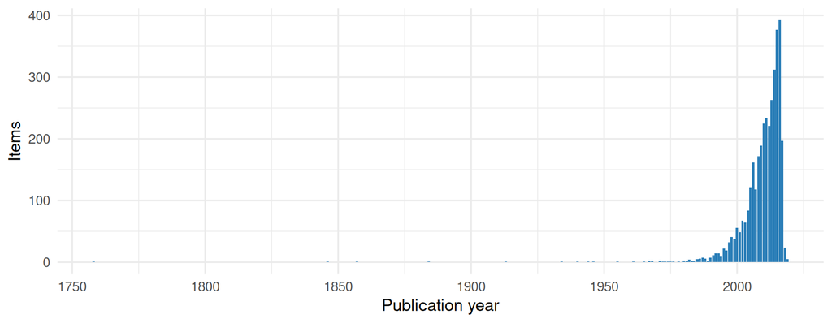

### Types of items

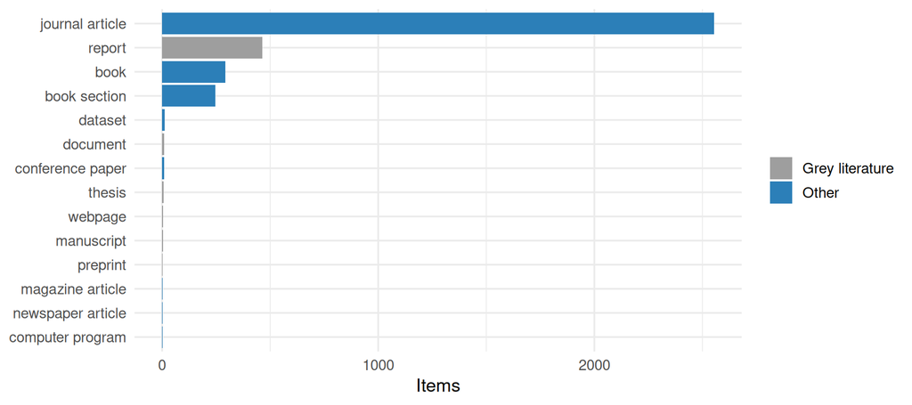

### Open access

Open access status of the publications found in OpenAlex. *Gold* and *diamond*: open in an open access journal; *hybrid*: open in a subscription journal; *green*: an open copy is in a repository; *bronze*: free to read on the publisher’s site; *closed*: not openly available.

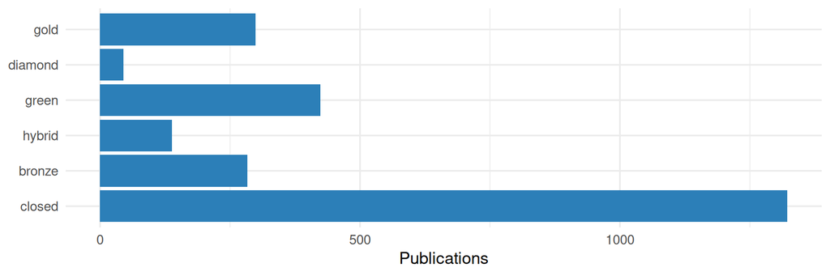

### Most frequent journals

| Journal | Items |
| --- | --- |
| Science | 121 |
| Nature | 72 |
| Proceedings of the National Academy of Sciences | 67 |
| Biological Conservation | 56 |
| PLoS ONE | 49 |
| BioScience | 46 |
| Conservation Biology | 45 |
| Global Change Biology | 45 |
| Ecological Economics | 38 |
| Forest Ecology and Management | 37 |

### Countries of the authors

Number of publications with at least one author from the country, for the publications found in OpenAlex.

| Country | Publications |
| --- | --- |
| United States | 1292 |
| United Kingdom | 385 |
| Brazil | 344 |
| Canada | 296 |
| Australia | 253 |
| Germany | 227 |
| Argentina | 167 |
| France | 157 |
| Netherlands | 152 |
| Chile | 141 |
| Spain | 141 |
| Mexico | 126 |
| Sweden | 110 |
| Switzerland | 97 |
| Italy | 91 |

## How the checks work

**NoteDetails of the checks**

#### identifiers

##### DOI coverage (`met_id_doi`)

Number and share of items with a valid DOI, and items whose DOI field is filled but contains no valid DOI. DOIs are extracted with `openalexPro::extract_doi()` and lower cased.

##### ISBN coverage (`met_id_isbn`)

Number and share of items with an ISBN, overall and for the item types which should have one (`book`, `bookSection`).

##### ISSN coverage (`met_id_issn`)

Number and share of items with an ISSN, overall and for the item types which should have one (`journalArticle`, `magazineArticle`).

##### ISSN not in the standard form (`met_id_issn_form`)

Items whose ISSN field is not in the standard form: each ISSN as `1234-567X` (with hyphen, capital X), several separated by “,”. The ISSNs are checked with their check digit. If all are valid, the standard form is proposed; otherwise the item is listed with the ISSNs which are not valid.

##### DOIs in the wrong field (`met_id_doi_misplaced`)

Items with an empty DOI field but a DOI in the `Url` or `Extra` field. These DOIs are not used for the OpenAlex lookup and should be moved to the DOI field.

##### DOIs in the wrong form (`met_id_doi_form`)

Items whose DOI field contains a valid DOI, but not as a bare DOI: as a link (`https://doi.org/10.…`), with a prefix (`doi:`, `DOI`), URL-encoded (`%5B` for `[`) or with spaces or other characters around it. Citation styles add the link themselves, so a link in the DOI field appears twice in a bibliography. The bare DOI is the one recognised by `openalexPro::extract_doi()`, keeping its upper and lower case.

##### Items without identifier (`met_id_none`)

Items with none of DOI, ISBN, ISSN or Url. These items can neither be checked against OpenAlex nor easily be retrieved by readers.

##### DOIs found in OpenAlex for items without a DOI (`met_id_candidates`)

For items without a DOI, OpenAlex was searched by title (see [get_doi_candidates()]). The works found are compared with the item: title (ignoring case and punctuation), year and the surname of the first author. A work is a *likely* match if the titles are (nearly) the same (similarity at least 0.95), the years differ by at most 1 and the first authors have the same surname (year or author are not compared if the item has none), and the title has at least 4 words (short titles like “Zoonoses” are too general). It is a *possible* match if the titles are similar (at least 0.8). All likely and possible works with a DOI are kept, sorted per item, best first. DOIs used by another item in the group are noted (the item would be a duplicate).

#### metadata

##### Filled fields per item type (`met_meta_fields`)

Percentage of items with a filled field, per item type, for the main fields: Title, Author, Publication Year, Publication Title, Publisher, DOI, ISBN, ISSN, Url, Abstract Note and Language. Not every field is expected for every item type, e.g. reports have no Publication Title.

##### Problematic publication years (`met_meta_year`)

Items whose date is missing (`missing`), from whose date Zotero could not derive a year (`unparseable`), or whose year lies in the future (`future`).

##### Duplicate items (`met_meta_duplicates`)

Items which are in the group more than once, identified by the same DOI, or by the same normalised title (lower case, letters and digits only), publication year and first word of the first author.

##### Language not given as a standard code (`met_meta_language`)

Items whose language is not given as a standard language code, i.e. a two-letter ISO 639-1 code, optionally with a region (`en`, `en-US`), but e.g. as a name (`English`), a three-letter code (`eng`) or in a different spelling (`EN`, `en_us`). Citation styles and other tools only recognise the codes. Where the value is recognised, the standard code is proposed, based on the ISO 639-2 list (R package ISOcodes): codes, three-letter codes and the English names of the languages. Other values, e.g. names in the language itself, several languages or other text, are listed without a proposal.

#### openalex_check

##### Zotero DOIs found in OpenAlex (`met_check_found`)

Valid Zotero DOIs which were / were not found in OpenAlex. A DOI which is not found is either not indexed by OpenAlex or wrong.

##### Retracted works (`met_check_retracted`)

Works flagged as retracted by OpenAlex, with the key of the Zotero item(s) with the same DOI.

##### Wrong DOIs (`met_check_mismatch`)

Items whose DOI points in OpenAlex to a work with a different title or year, which usually means that the wrong DOI is attached to the item. An item is flagged when the title similarity (normalised Levenshtein distance) is below 0.8 or the years differ by more than one.

##### Item type agreement (`met_check_type`)

Zotero item type compared with the OpenAlex work type for items with the same DOI.

##### Missing dates found in OpenAlex (`met_check_date`)

Items without a date whose DOI was found in OpenAlex: the publication date in OpenAlex is proposed. OpenAlex gives 1 January when only the year is known, so such dates are proposed as the year only. Items whose DOI points to a different publication are left out.

##### Empty fields found in OpenAlex (`met_check_fill`)

Journal articles with an empty journal, volume, issue or pages field whose DOI was found in OpenAlex with these details: the values in OpenAlex are proposed. The journal is only taken if the publication is in a journal in OpenAlex (not e.g. a repository). Page ranges which end before they start (e.g. `1260-2`, shortened or wrong) are not proposed. Items whose DOI points to a different publication are left out.

##### OpenAlex ID in the Extra field (`met_check_openalex_id`)

Items whose DOI was found in OpenAlex, compared with the OpenAlex ID noted in their Extra field (a line `OpenAlex: W…`). Items without such a line can get it, which links them to OpenAlex for later checks. Items with a different ID are listed for checking: OpenAlex merges records, and the ID of a merged record redirects to the new one. Items whose DOI points to a different publication are left out.

##### OpenAlex ID in the Extra field not valid (`met_check_extra_id`)

Checks the lines `OpenAlex: …` in the Extra field (looked up by [get_extra_ids()]). A line is not valid if - it is not an OpenAlex work ID (`W` and digits), - the item has several lines with different IDs, - the ID is not in OpenAlex (wrong, or merged into another record), or - the work is a different publication: its DOI is not the DOI of the item, or, for items without DOI, its title is not similar (similarity below 0.8, see [title_similarity()]).

#### profile

##### Publication years (`met_prof_year`)

Number of items per publication year, with cumulative counts. Items without a year are counted as `NA`.

##### Open access status (`met_prof_oa`)

OpenAlex open access status (gold, diamond, green, hybrid, bronze, closed) of the works, overall and per publication year.

##### Top journals (`met_prof_journals`)

The 50 most frequent journals, from the Publication Title in Zotero and the source of the primary location in OpenAlex. Ties at rank 50 are included.

##### Author countries (`met_prof_countries`)

Number of works with at least one author affiliated with an institution in a country, per country (ISO 3166-1 alpha-2 codes from OpenAlex).

##### Item types and grey literature (`met_prof_types`)

Number of items per item type (Zotero) or work type (OpenAlex), and the share of grey literature, i.e. reports, theses, dissertations, web pages, documents, presentations, manuscripts, blog posts and preprints.

##### Languages (`met_prof_language`)

Languages as entered, and normalised to two letter codes (lower case, region removed, English spellings mapped to `en`). Inconsistent codes in the language as entered are a quality issue in themselves.

#### maintenance

##### Group activity (`met_maint_activity`)

Items added per month, and items added / modified in the 30 days before the metrics were calculated.

##### Items without tags (`met_maint_tags`)

Items without manual tags. Automatic tags, e.g. keywords imported from the publisher, are ignored.

IPBES Literature Report 0.4.0 · [source code on GitHub](https://github.com/IPBES-Data/IPBES.LiteratureReport) (© IPBES.LiteratureReport authors, [MIT licence](https://opensource.org/license/mit)) · reports and data on this website: [CC0 1.0](https://creativecommons.org/publicdomain/zero/1.0/) (no rights reserved)